# STSCI 4630 - Spring 2019 - HW4

Da (Harry) Lu, dl947

Due Tuesday, Feb/28/2019

# Question 1

[10 points] Run lines 1 to 4. Adapt lines 5 and 6 to produce time series plots for the prices and returns from United Technologies (UTX). Submit your plots. Do the plots show evidence of non-stationarity? Justify your answer briefly.

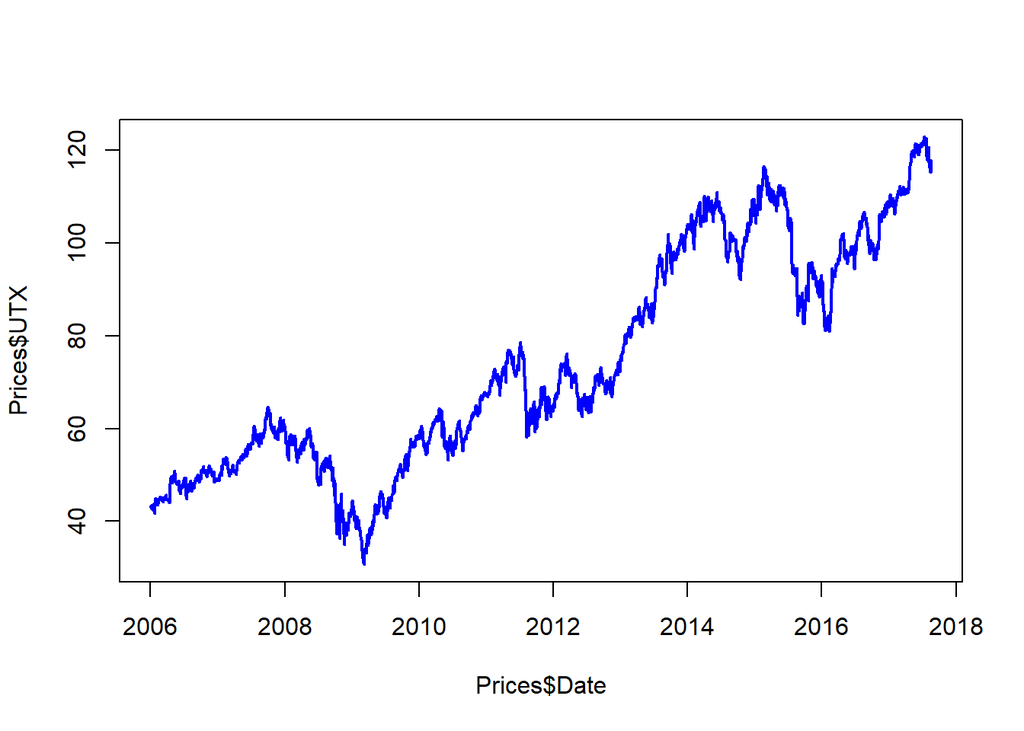

```r
plot(Prices$Date , Prices$UTX, type="l", lwd=2, col="blue")
```

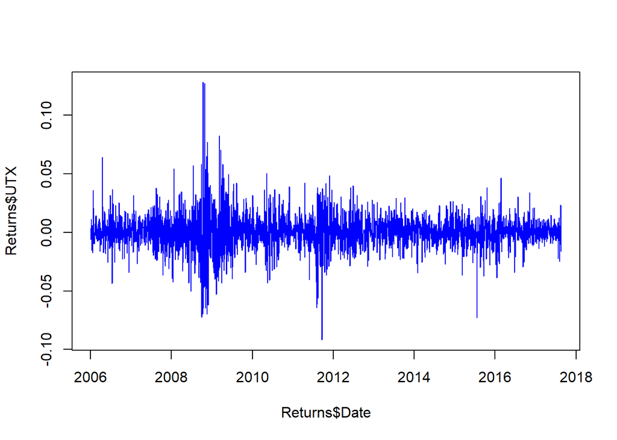

```r
plot(Returns$Date, Returns$UTX, type="l", lwd=1, col="blue")
```

The plots show evidence of non-stationarity. The mean is not constant with time and the variance also appears to be changing with time.

# Question 2

[5 points] By adapting line 7, produce a plot of the sample ACF for the returns from United Technologies (UTX). Submit your plot. Does the plot show evidence of serial autocorrelation? Justify your answer briefly.

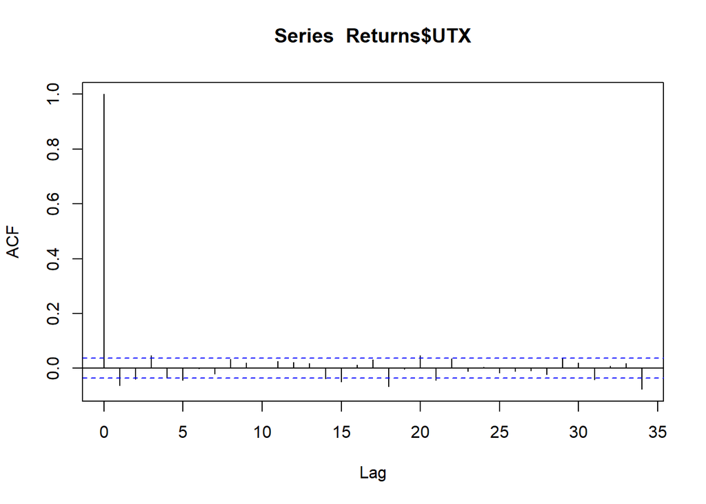

```r
acf(Returns$UTX)
```

There is evidence of serial autocorrelation since lag 1 is significant.

# Question 3

```r
Box.test(Returns$UTX, lag=5, type="Ljung-Box")
```

```
##
##  Box-Ljung test
##
## data:  Returns$UTX
## X-squared = 30.958, df = 5, p-value = 9.55e-06
```

Yes, the $p$-value is close to 0.

# Question 4

```r
fit=arima(Returns$UTX, order=c(1,0,0))
fit
```

```
##
## Call:
## arima(x = Returns$UTX, order = c(1, 0, 0))
##
## Coefficients:
##           ar1  intercept
##       -0.0622      3e-04
## s.e.   0.0184      3e-04
##
## sigma^2 estimated as 0.000215:  log likelihood = 8206.15,  aic = -16406.3
```

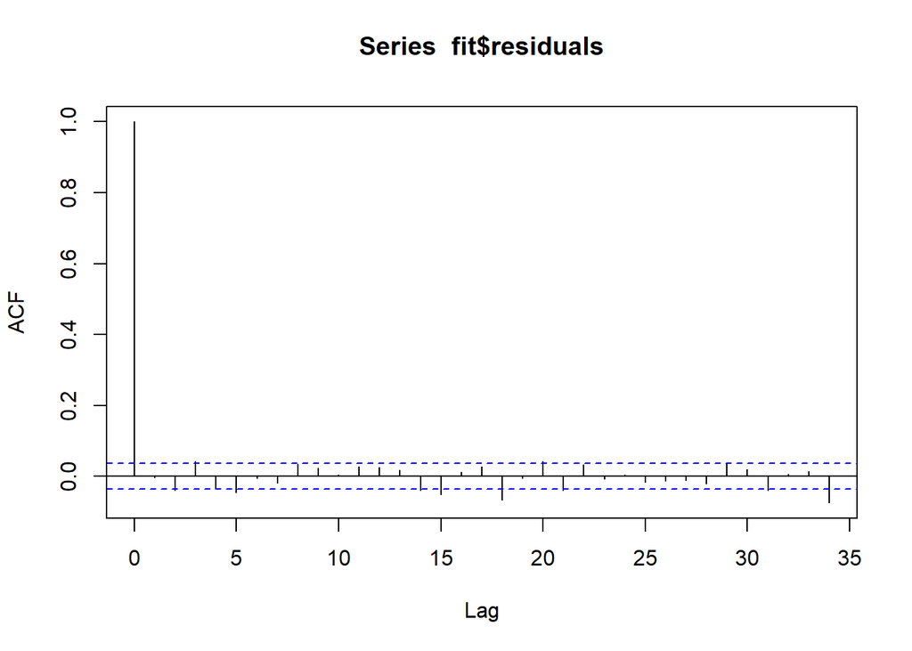

```r
acf(fit$residuals)
```

```r
Box.test(fit$residuals, lag=10, type="Ljung-Box", fitdf=1)
```

```
##
##  Box-Ljung test
##
## data:  fit$residuals
## X-squared = 25.496, df = 9, p-value = 0.002469
```

```r
AIC(fit)
```

```
## [1] -16406.3
```

```r
BIC(fit)
```

```
## [1] -16388.36
```

The are some lags are significant, so there should be autocorrelation. Also, the $p$-value is close to 0. However, it should not be a AR(1) because there is not lag at $t=1$.

# Question 5

[15 points] By adapting lines 31 to 34, fit the AR(4) model to the returns from United Technologies (UTX). Use $K=15$ for the Ljung-Box test. Submit your output. Do the plot and the test show evidence of serial autocorrelation? Justify your answer briefly. Do the plot and test suggest that the AR(4) model is appropriate for the returns?

```r
fit=arima(Returns$UTX, order=c(4,0,0))
fit
```

```
##
## Call:
## arima(x = Returns$UTX, order = c(4, 0, 0))
##
## Coefficients:
##           ar1      ar2     ar3      ar4  intercept
##       -0.0619  -0.0413  0.0397  -0.0303      3e-04
## s.e.   0.0185   0.0185  0.0185   0.0185      2e-04
##
## sigma^2 estimated as 0.000214:  log likelihood = 8212.7,  aic = -16413.41
```

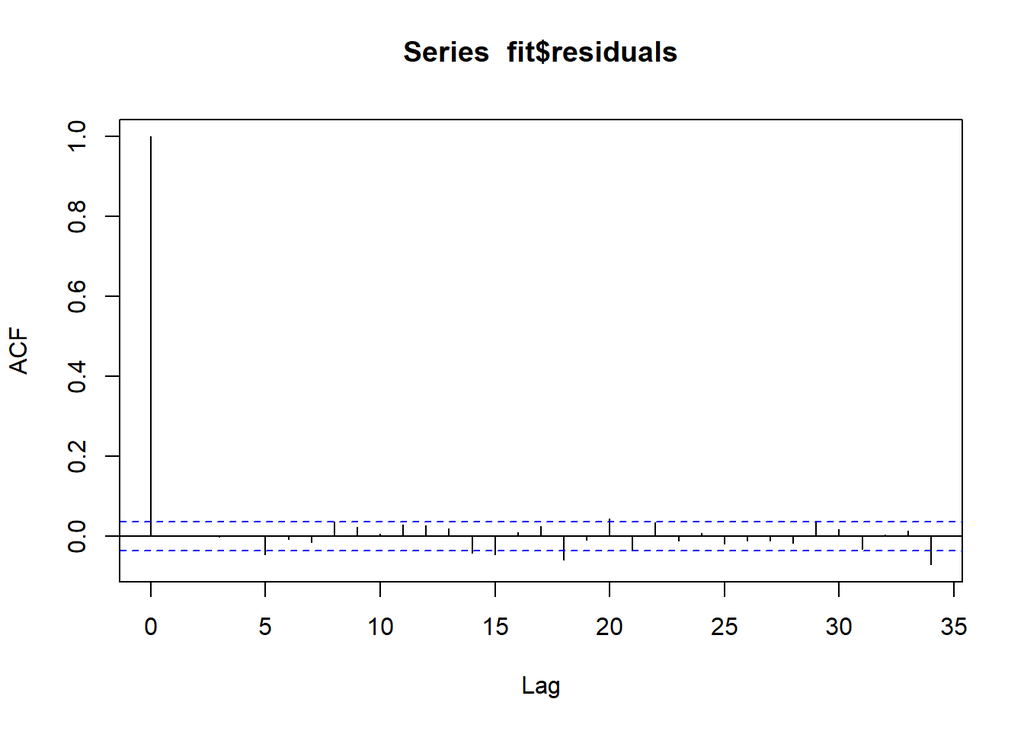

```r
acf(fit$residuals)
```

```r
Box.test(fit$residuals, lag=15, type="Ljung-Box", fitdf=4)
```

```
##
##  Box-Ljung test
##
## data:  fit$residuals
## X-squared = 29.628, df = 11, p-value = 0.001812
```

Yes, $p$-value is less than 0.05. However, AR(4) is not appropriate because there are not lags before $t=5$.

# Question 6

[15 points] By adapting lines 52 to 55, fit the MA(5) model to the returns from United Technologies (UTX). Use $K=13$ for the Ljung-Box test. Submit your output. Do the plot and the test show evidence of serial autocorrelation? Justify your answer briefly. Do the plot and test suggest that the MA(5) model is appropriate for the returns?

```r
fit=arima(Returns$UTX, order=c(0,0,5))
fit
```

```
##
## Call:
## arima(x = Returns$UTX, order = c(0, 0, 5))
##
## Coefficients:
##           ma1      ma2     ma3      ma4      ma5  intercept
##       -0.0636  -0.0367  0.0456  -0.0322  -0.0467      3e-04
## s.e.   0.0185   0.0185  0.0185   0.0179   0.0186      2e-04
##
## sigma^2 estimated as 0.0002135:  log likelihood = 8215.85,  aic = -16417.7
```

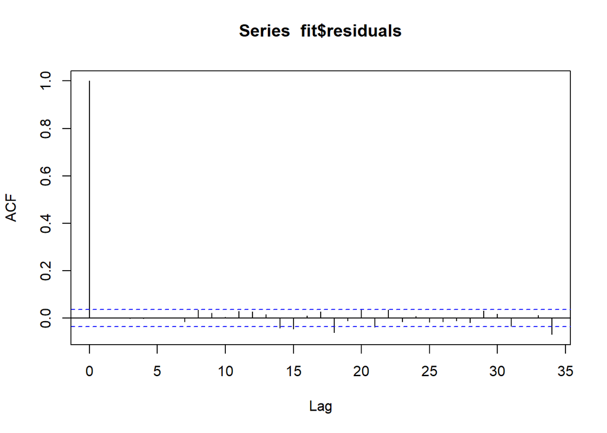

```r
acf(fit$residuals)
```

```r
Box.test(fit$residuals, lag=13, type="Ljung-Box", fitdf=5)
```

```
##
##  Box-Ljung test
##
## data:  fit$residuals
## X-squared = 10.667, df = 8, p-value = 0.2213
```

No, $p$-value is 0.2213 which is greater than 0.05. The test suggest than the MA(5) model is appropriate. However, the plot stills has no lags before $t=6$, which means that the plot does not suggest the MA(5) is appropriate.

# Question 7

[5 points] Based on the AIC information criterion, would the AR(4) model or the MA(5) model for the returns from United Technologies (UTX) be preferred? Justify your answer.

```r
AIC(arima(Returns$UTX, order=c(4,0,0))) #AR(4)
```

```
## [1] -16413.41
```

```r
AIC(arima(Returns$UTX, order=c(0,0,5))) #MA(5)
```

```
## [1] -16417.7
```

From the AIC values, the AIC value of MA(5) is smaller so MA(5) is preferred.

# Question 8

[10 points] Run lines 60 and 61 to install the package `forecast`. By adapting line 64, find the best fitting ARMA(p,q) model for the returns from United Technologies (UTX) as identified by the `auto.arima()` function using the AIC criterion. Submit your output. Based on the AIC information criterion, would you prefer the model determined in this question or would you prefer the MA(5) model?

```r
#install.packages("forecast")
library("forecast")
#auto.arima(Returns$UTX, max.p=20, max.q=0, d=0, ic="aic")
#auto.arima(Returns$UTX, max.p=0, max.q=20, d=0, ic="aic")
auto.arima(Returns$UTX, max.p=20, max.q=20, d=0, ic="aic")
```

```
## Series: Returns$UTX
## ARIMA(2,0,4) with zero mean
##
## Coefficients:
##          ar1      ar2      ma1     ma2     ma3      ma4
##       0.3626  -0.8254  -0.4254  0.8118  0.0010  -0.0572
## s.e.  0.0746   0.0809   0.0764  0.0839  0.0242   0.0218
##
## sigma^2 estimated as 0.000214:  log likelihood=8215.72
## AIC=-16417.44   AICc=-16417.41   BIC=-16375.57
```

```r
#auto.arima(Returns$UTX, ic="aic")
```

The AIC value from MA(5), -16417.7, is slightly smaller than the ACI value from the auto-model, -16417.44. So MA(5) is preferred.

# Question 9

[10 points] By adapting lines 66 to 68, fit an ARIMA(2,1,2) model to the prices from United Technologies (UTX), and find point predictions along with 75% and 90% prediction intervals for the next 7 prices. Submit your output. What is the point prediction of the price for period $t=2932$? What is the 75% prediction interval for the price at period $t=2934$.

```r
library(knitr)
fit=arima(Returns$UTX, order=c(2,1,2))
fc=forecast(fit, h=7, level=c(75,90))
kable(fc)
```

|  | Point Forecast | Lo 75 | Hi 75 | Lo 90 | Hi 90 |
| --- | --- | --- | --- | --- | --- |
| 2928 | 0.0021800 | -0.0146644 | 0.0190244 | -0.0219053 | 0.0262653 |
| 2929 | -0.0002351 | -0.0171130 | 0.0166428 | -0.0243684 | 0.0238982 |
| 2930 | 0.0005055 | -0.0163886 | 0.0173996 | -0.0236510 | 0.0246619 |
| 2931 | 0.0002867 | -0.0166149 | 0.0171883 | -0.0238805 | 0.0244539 |
| 2932 | 0.0003492 | -0.0165538 | 0.0172521 | -0.0238199 | 0.0245183 |
| 2933 | 0.0003319 | -0.0165712 | 0.0172351 | -0.0238375 | 0.0245013 |
| 2934 | 0.0003365 | -0.0165666 | 0.0172397 | -0.0238329 | 0.0245059 |

# Question 10

[10 points] By adapting lines 69 to 71, plot the point predictions of the prices from Proctor & Gamble (PG) along with the 50%, 75%, and 95% prediction intervals for the next 500 periods based on the ARIMA(2,1,2) model. Submit your plot.

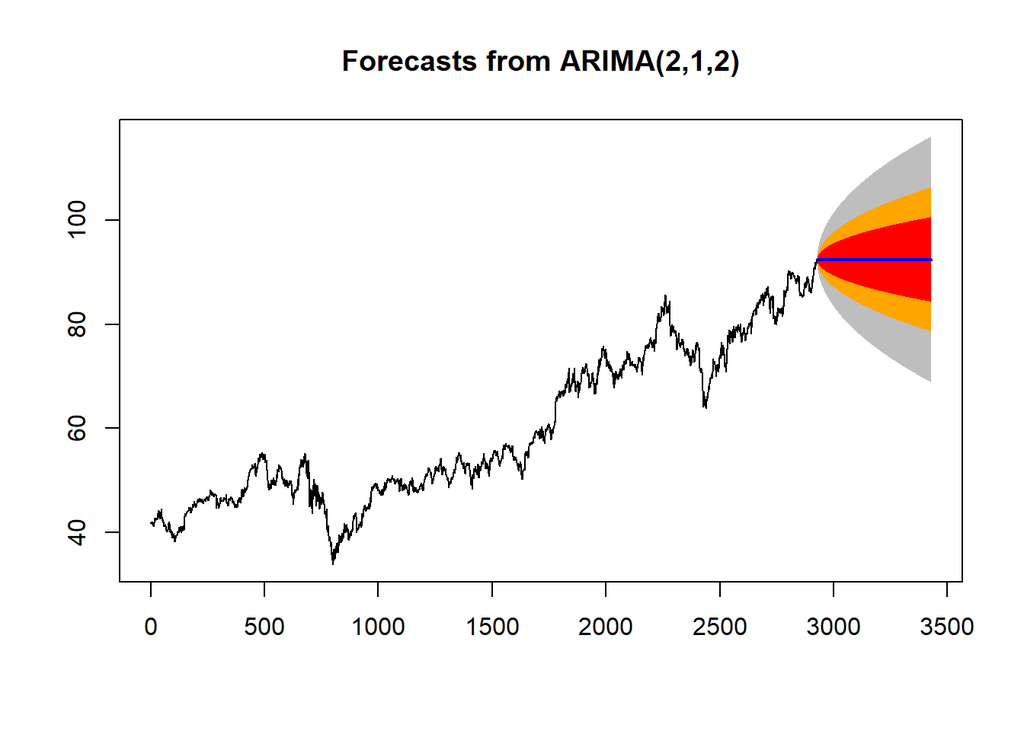

```r
fit=arima(Prices$PG, order=c(2,1,2))
fc=forecast(fit, h=500, level=c(50,75,95))
plot(fc,shadecols=c("gray","orange","red"))
```